# Herramientas para el Análisis de Series de Tiempo en R - Ejercitación 4

Oficina de la CEPAL en Buenos Aires

Octubre 2021

# Objetivos

1. Estimar un modelo VAR para la tasa de préstamos personales y la de política monetaria, y
2. Resolver el ejercicio pendiente, que consistía en estimar un modelo de corrección de errores para el empleo como función del producto.

# Ejercitación clase 4: VAR para las tasas de interés

## Carga de datos

Empezamos limpiando la memoria, cargando las librerías y estableciendo el directorio. Incorporamos el paquete `vars` para estimar modelos VAR.

```r
##  Limpiar la memoria
rm(list=ls())

## Apertura de librerias
library(tidyverse)  #Manejo de bases de datos y otros
library(openxlsx)   #Lectura de xlsx
library(lubridate)  #Manejo de variables en formato fecha
library(zoo)        #Series de tiempo
library(forecast)   #Pronosticos
library(ggfortify)  #Graficos
library(fUnitRoots) #adfTest y otros
library(kableExtra) #Formato tablas
library(vars)       #Modelos VAR

## Establecemos el directorio
setwd("C:/Users/Garlan/Desktop/CEPAL/Curso Series")

options(scipen=9999) #Evita que los resultados se impriman en notación científica
```

Retomamos la base que habíamos armado con tasas mensualizadas y filtramos los períodos con un cambio en el régimen de política. Con `across(everything())` aplicamos una misma función a todo el data.frame: convertimos a series de tiempo. Luego aplicamos `attach()`, que nos va a permitir llamar las del data.frame como si fueran objetos.

```r
tasas <- read.xlsx("Clase 4.xlsx", sheet="tasas_mensual") %>%
  dplyr::filter(year<2020) %>%
  mutate(across(everything(), .fns = ts, start = c(2016,1), frequency = 12))

attach(tasas)
```

Calculamos las primeras diferencias (ya habíamos testeado que son estacionarias) y graficamos.

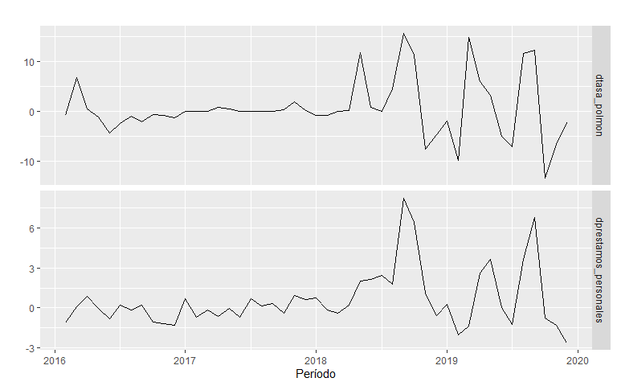

```r
dtasa_polmon <-  tasa_polmon - stats::lag(tasa_polmon,-1)
dprestamos_personales <-  prestamos_personales - stats::lag(prestamos_personales,-1)

autoplot(cbind(dtasa_polmon,dprestamos_personales), facets=TRUE)+
  labs(x="Período", y="")
```

Tomemos 5’ o 10’ para estimar el VAR.

- Usar `VARselect()` para seleccionar la cantidad de rezagos.
- Estimar el VAR.

## Estimación

En primer lugar seleccionamos la cantidad de rezagos mediante `VARselect()[["selection"]]`. El parámetro “const” simplemente indica que las ecuaciones del modelo tienen intercepto. Por defecto el máximo orden en 10.

```r
VARselect(cbind(dtasa_polmon,dprestamos_personales), type="const")[["selection"]]
```

```
## AIC(n)  HQ(n)  SC(n) FPE(n)
##     10      6      1      9
```

Vemos que el criterio AIC sugiere 10 rezagos, mientras que el BIC 1. Realizamos la estimación con 1, por lo que el modelo a estimar, llamando $TPM$ a la tasa de política monetaria y $PP$ a la de préstamos personales, es:

$$\begin{aligned}
\Delta TPM_t = \beta_{10}&+ \beta_{11} \ \Delta TPM_{t-1}+ \beta_{12} \ \Delta PP_{t-1} + \varepsilon_{1t} \\
\Delta PP_t = \beta_{20}&+ \beta_{21} \ \Delta PP_{t-1} + \beta_{22} \ \Delta TPM_{t-1} + \varepsilon_{2t}
\end{aligned}$$

Para estimar el modelo usamos la función `VAR()`, agregando una constante y con 1 rezago (p=1). Mediante `summary()` podemos evaluar la significatividad estadística de los coeficientes, pero no pueden interpretarse de la misma manera que las regresiones que vimos hasta ahora porque no asumimos exogeneidad, sino que todas las variables son endógenas y simétricas. Por el momento, lo que interesa es el resultado de la proyección.

```r
var <- VAR(cbind(dtasa_polmon,dprestamos_personales), p=1, type="const")

summary(var)
```

```
##
## VAR Estimation Results:
## =========================
## Endogenous variables: dtasa_polmon, dprestamos_personales
## Deterministic variables: const
## Sample size: 46
## Log Likelihood: -214.78
## Roots of the characteristic polynomial:
## 0.447 0.447
## Call:
## VAR(y = cbind(dtasa_polmon, dprestamos_personales), p = 1, type = "const")
##
##
## Estimation results for equation dtasa_polmon:
## =============================================
## dtasa_polmon = dtasa_polmon.l1 + dprestamos_personales.l1 + const
##
##                          Estimate Std. Error t value Pr(>|t|)
## dtasa_polmon.l1            0.3487     0.2009   1.735   0.0898 .
## dprestamos_personales.l1  -0.8813     0.5612  -1.570   0.1237
## const                      1.0162     0.9265   1.097   0.2789
## ---
## Signif. codes:  0 '***' 0.001 '**' 0.01 '*' 0.05 '.' 0.1 ' ' 1
##
##
## Residual standard error: 5.948 on 43 degrees of freedom
## Multiple R-Squared: 0.07116, Adjusted R-squared: 0.02795
## F-statistic: 1.647 on 2 and 43 DF,  p-value: 0.2045
##
##
## Estimation results for equation dprestamos_personales:
## ======================================================
## dprestamos_personales = dtasa_polmon.l1 + dprestamos_personales.l1 + const
##
##                          Estimate Std. Error t value Pr(>|t|)
## dtasa_polmon.l1           0.16993    0.06224   2.730  0.00914 **
## dprestamos_personales.l1  0.14349    0.17383   0.825  0.41367
## const                     0.42300    0.28702   1.474  0.14782
## ---
## Signif. codes:  0 '***' 0.001 '**' 0.01 '*' 0.05 '.' 0.1 ' ' 1
##
##
## Residual standard error: 1.843 on 43 degrees of freedom
## Multiple R-Squared: 0.3267,  Adjusted R-squared: 0.2953
## F-statistic: 10.43 on 2 and 43 DF,  p-value: 0.0002027
##
##
##
## Covariance matrix of residuals:
##                       dtasa_polmon dprestamos_personales
## dtasa_polmon                35.380                 8.691
## dprestamos_personales        8.691                 3.395
##
## Correlation matrix of residuals:
##                       dtasa_polmon dprestamos_personales
## dtasa_polmon                 1.000                 0.793
## dprestamos_personales        0.793                 1.000
```

## Pronóstico

Para hacer el pronóstico manualmente necesitaríamos acceder a los coeficientes, por ejemplo mediante `coef()`. Como en un VAR hay más de una ecuación, los coeficientes se guardan en una lista, cada uno de cuyos elementos corresponde a una ecuación. Podemos acceder a cada elemento de una lista con corchetes dobles.

```r
class(coef(var))
```

```
## [1] "list"
```

```r
coef_polmon <- coef(var)[[1]]
coef_prestamos <- coef(var)[[2]]

coef_polmon
```

```
##                            Estimate Std. Error   t value  Pr(>|t|)
## dtasa_polmon.l1           0.3486725  0.2009252  1.735335 0.0898441
## dprestamos_personales.l1 -0.8812680  0.5611709 -1.570409 0.1236502
## const                     1.0161898  0.9265479  1.096748 0.2788557
```

La función `forecast()` permite generar un pronóstico automáticamente, lo cual es posible porque las variables en $t+1$ dependen exclusivamente de su valor en $t$, que es conocido. En particular, no hay variables exógenas cuyos valores futuros haya que pre-determinar para hacer el pronóstico (como hicimos, por ejemplo, con el MCE). El parámetro `h` fija el horizonte de la proyección.

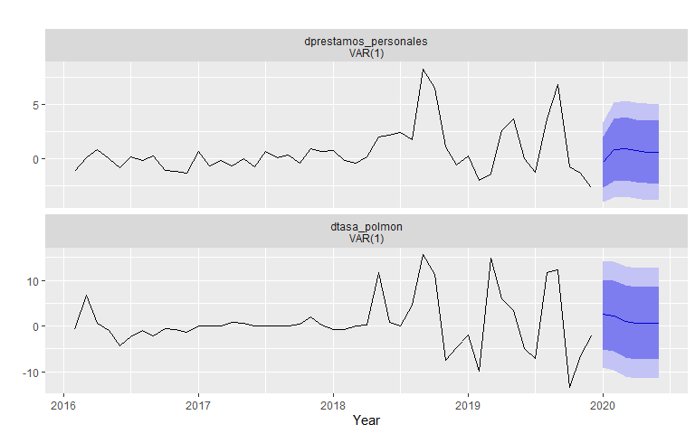

```r
autoplot(forecast(var, h=6)) + xlab("Year")
```

Para acceder a los valores pronosticados entramos al objeto `forecast` dentro del pronóstico. Es una lista cuyo primer elemento es el pronóstico para `dtasa_polmon`, y el segundo para `dprestamos_personales`. Las estimaciones puntuales se guardan bajo el nombre de `mean`.

```r
forecast(var)$forecast
```

```
## $dtasa_polmon
##          Point Forecast     Lo 80     Hi 80      Lo 95    Hi 95
## Jan 2020      2.5811810 -5.041602 10.203964  -9.076859 14.23922
## Feb 2020      2.2014028 -5.591520  9.994326  -9.716844 14.11965
## Mar 2020      1.0653599 -6.819669  8.950389 -10.993751 13.12447
## Apr 2020      0.5821147 -7.334709  8.498938 -11.525622 12.68985
## May 2020      0.5712452 -7.347472  8.489963 -11.539388 12.68188
## Jun 2020      0.6624418 -7.256814  8.581698 -11.449015 12.77390
## Jul 2020      0.7094970 -7.210019  8.629013 -11.402357 12.82135
## Aug 2020      0.7144361 -7.205101  8.633974 -11.397451 12.82632
## Sep 2020      0.7074659 -7.212075  8.627006 -11.404426 12.81936
## Oct 2020      0.7030486 -7.216494  8.622591 -11.408846 12.81494
##
## $dprestamos_personales
##          Point Forecast     Lo 80    Hi 80     Lo 95    Hi 95
## Jan 2020     -0.3236542 -2.684977 2.037668 -3.934986 3.287677
## Feb 2020      0.8151875 -2.024649 3.655024 -3.527968 5.158343
## Mar 2020      0.9140657 -1.959217 3.787349 -3.480241 5.308373
## Apr 2020      0.7352043 -2.143550 3.613959 -3.667471 5.137879
## May 2020      0.6274205 -2.254730 3.509571 -3.780448 5.035289
## Jun 2020      0.6101073 -2.272405 3.492619 -3.798315 5.018529
## Jul 2020      0.6231202 -2.259422 3.505662 -3.785348 5.031588
## Aug 2020      0.6329836 -2.249584 3.515551 -3.775523 5.041490
## Sep 2020      0.6352382 -2.247333 3.517809 -3.773274 5.043751
## Oct 2020      0.6343773 -2.248194 3.516949 -3.774135 5.042890
```

```r
dtasa_polmon_p <- forecast(var)$forecast$dtasa_polmon$mean
dprestamos_personales_p <- forecast(var)$forecast$dprestamos_personales$mean

dtasa_polmon_p
```

```
##            Jan       Feb       Mar       Apr       May       Jun       Jul
## 2020 2.5811810 2.2014028 1.0653599 0.5821147 0.5712452 0.6624418 0.7094970
##            Aug       Sep       Oct
## 2020 0.7144361 0.7074659 0.7030486
```

Podríamos replicar el pronóstico para la variable en niveles sumándole al valor conocido en $t$ la diferencia pronosticada para $t+1$, e iterando. Por ejemplo, para la tasa de política monetaria calculamos:

$$\begin{aligned}
TPM_{t+1}^p&=TPM_{t}+\Delta TPM_{t+1}^p
\end{aligned}$$

donde el supraíndice *p* indica los valores pronosticados. Para $t=48$ tasa_polmon es conocida, mientras que para los períodos posteriores es el valor pronosticado (por ser una proyección dinámica).

- Guardamos las diferencias pronosticadas en los períodos sucesivos a la serie original.
- Creamos las variables donde vamos a cargar el pronóstico.

```r
dtasa_polmon_p <- c(dtasa_polmon, dtasa_polmon_p)
dprestamos_personales_p <- c(dprestamos_personales, dprestamos_personales_p)

tasa_polmon_p <- tasa_polmon
prestamos_personales_p <- prestamos_personales
```

Ahora, usando un loop, construimos el pronóstico sumando a cada variable en $t-1$ la diferencia pronosticada para el período $t$, lo cual nos devuelve el nivel pronosticado en $t$.

```r
for (t in 49:54) {
tasa_polmon_p <- c(tasa_polmon_p,
                     tasa_polmon_p[t-1]+dtasa_polmon_p[t])
prestamos_personales_p <- c(prestamos_personales_p,
                            prestamos_personales_p[t-1]+dprestamos_personales_p[t])
}

# Otra opción es calcular manualmente el pronóstico mediante los coeficientes

# for (t in 49:54) {
#   tasa_polmon_p <- c(tasa_polmon_p,
#                      tasa_polmon_p[t-1]+
#                        coef_polmon[3]+
#                        coef_polmon[1]*dtasa_polmon_p[t-1]+
#                        coef_polmon[2]*dprestamos_personales_p[t-1])
#   prestamos_personales_p <- c(prestamos_personales_p,
#                               prestamos_personales_p[t-1]+
#                                 coef_prestamos[3]+
#                                 coef_prestamos[1]*dtasa_polmon_p[t-1]+
#                                 coef_prestamos[2]*dprestamos_personales_p[t])
# }
```

Finalmente, para graficar convertimos nuevamente a series de tiempo.

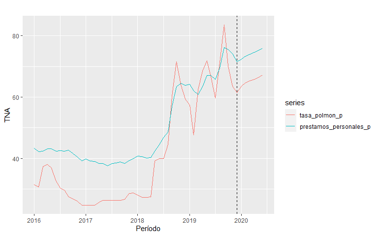

```r
tasa_polmon_p <- ts(tasa_polmon_p, start = c(2016,1), frequency = 12)
prestamos_personales_p <- ts(prestamos_personales_p, start = c(2016,1), frequency = 12)

autoplot(cbind(tasa_polmon_p,prestamos_personales_p))+
  labs(x="Período", y="TNA")+
  geom_vline(xintercept = 2019.92, linetype="dashed") #2019.92 = dic-19
```

Este modelo ajusta peor a lo que hoy sabemos que sucedió que el MCE porque en este último incorporamos conocimiento sobre la variable de política. Esta metodología VAR es “agnóstica” respecto a qué variables son endógenas y cuáles no, por lo que aplica mejor cuando esperamos que estas mantengan su trayectoria (conjunta) histórica. También podrían incorporarse shocks exógenos sobre algunas de estas variables endógenas. Si bien no podemos verlo en detalle, estos shocks pueden visualizarse a través de lo que se conoce como función impulso-respuesta, de la siguiente manera:

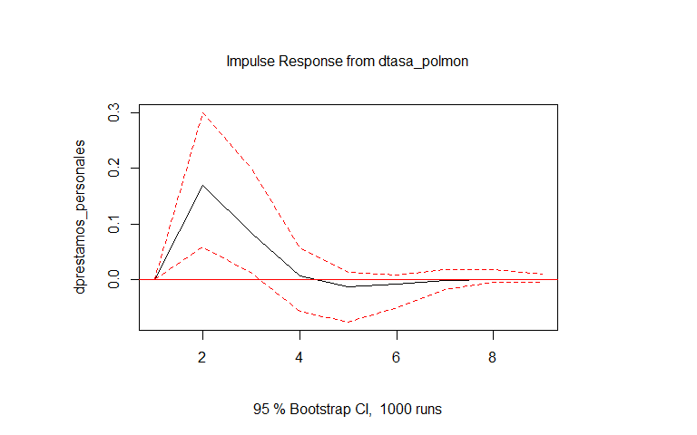

```r
#Forecast error impulse response

feir <- irf(var, impulse = "dtasa_polmon", response = "dprestamos_personales",
             n.ahead = 8, ortho = FALSE, runs = 1000)

plot(feir)
```

Notar que el primer valor es cero porque no hay efectos contemporáneos en ninguna de las ecuaciones. Para incorporar efectos contemporáneos entre las variables habría que emplear estrategias como la descomposición de Cholesky, donde se rompe la relación de simetría haciendo supuestos de identificación sobre el orden de exogeneidad a las variables. Para más detalles se sugiere ver el libro de Enders.

## Selección de modelos de pronóstico alternativos

Supongamos nuevamente que no contamos con información para períodos posteriores a diciembre de 2019, y que queremos evaluar dos modelos alternativos para pronosticar la tasa de préstamos personales en un contexto donde todas las variables son endógenas. Para estimar un VAR, como vimos, necesitamos que las series sean estacionarias. Para eso, tomamos primeras diferencias.

$$\begin{aligned}
\Delta PP_t &= c_1 +\beta_1 \ \Delta PP_t +\epsilon_t \\
PP_t &= c_1 +\beta_1 \ \Delta PP_t +\beta_2 \ \Delta \text{Liquidez}_t+\varepsilon_t
\end{aligned}$$

donde $\text{Liquidez}_t$ es la liquidez bancaria, calculada como la suma de la cuenta corriente en el BC, las LELIQs y los pases pasivos sobre los depósitos (también descargados de `seriese.xlsx` del BCRA). La variable se encuentra disponible, ya mensualizada, en `tasas`.

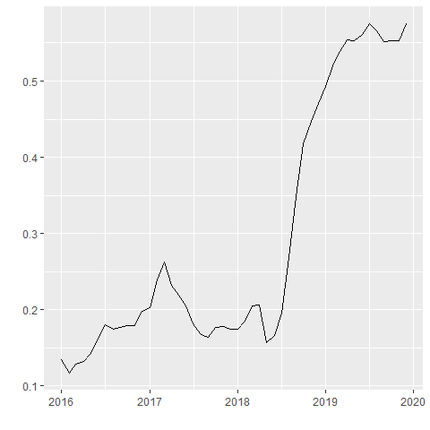

```r
autoplot(liquidez)
```

Notemos que la serie es integrada de orden 1.

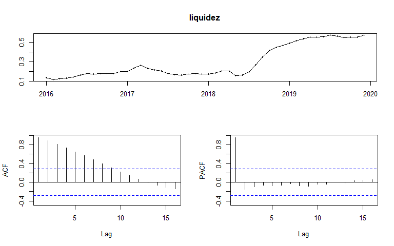

```r
tsdisplay(liquidez)
```

```r
adfTest(liquidez, lags=1, type = "ct")
```

```
##
## Title:
##  Augmented Dickey-Fuller Test
##
## Test Results:
##   PARAMETER:
##     Lag Order: 1
##   STATISTIC:
##     Dickey-Fuller: -1.8752
##   P VALUE:
##     0.624
##
## Description:
##  Tue Oct 26 15:59:52 2021 by user: Garlan
```

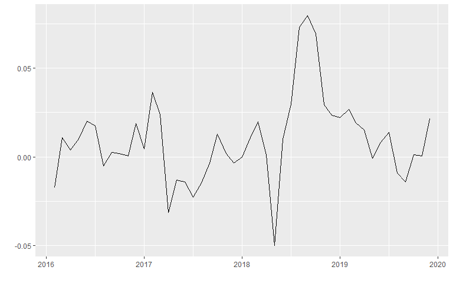

```r
dliquidez <- liquidez - stats::lag(liquidez,-1)
autoplot(dliquidez)
```

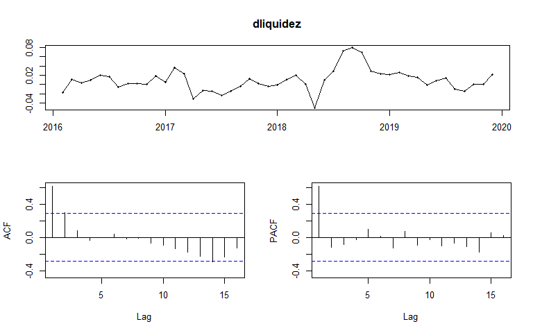

```r
tsdisplay(dliquidez)
```

```r
adfTest(dliquidez, type = "nc")
```

```
##
## Title:
##  Augmented Dickey-Fuller Test
##
## Test Results:
##   PARAMETER:
##     Lag Order: 1
##   STATISTIC:
##     Dickey-Fuller: -2.8913
##   P VALUE:
##     0.01
##
## Description:
##  Tue Oct 26 15:59:52 2021 by user: Garlan
```

Siguiendo con la evaluación, dividimos la muestra en la de entrenamiento (una para cada modelo) y de prueba (solo la variable que nos interesa pronosticar). `window()` permite recortar las series según los parámetros especificados, a diferencia de `ts()`, que solo declara el período de la serie.

```r
entrenamiento1 <- window(cbind(dprestamos_personales,dtasa_polmon),
                         start = c(2016,2), end = c(2019,4))
entrenamiento2 <- window(cbind(dprestamos_personales,dtasa_polmon,dliquidez),
                         start = c(2016,2), end = c(2019,4))

prueba <- window(dprestamos_personales, start = c(2019,5), end = c(2019,12), frequency = 12)
```

Ahora estimamos cada uno de los modelos y guardamos el pronóstico. Para la selección se rezagos máximos, tener en cuenta que se pierden muchos grados de libertad y la muestra no es tan grande: con 3 rezagos en el VAR de 2 variables perdemos 8, con 2 rezagos en el VAR de dimension 3 perdemos 9 (aprox. 20% de la muestra). Fijamos un horizonte de pronóstico de 8 períodos, que es el tamaño de la muestra de prueba.

```r
VARselect(entrenamiento1, lag.max = 3, type = "const")[["selection"]]
```

```
## AIC(n)  HQ(n)  SC(n) FPE(n)
##      1      1      1      1
```

```r
VARselect(entrenamiento2, lag.max = 2, type = "const")[["selection"]]
```

```
## AIC(n)  HQ(n)  SC(n) FPE(n)
##      1      1      1      1
```

```r
var1 <- forecast(VAR(entrenamiento1, p=1,type="const"),h=8)
var2 <- forecast(VAR(entrenamiento2, p=1,type="const"),h=8)
```

Recuperamos los pronósticos para la (diferencia de la) tasa de préstamos personales.

```r
dprestamos_personales_adj1 <- var1$forecast$dprestamos_personales$mean
dprestamos_personales_adj2 <- var2$forecast$dprestamos_personales$mean
```

Ahora aplicamos las métricas de selección.

```r
a1 <- accuracy(dprestamos_personales_adj1,prueba)
a2 <- accuracy(dprestamos_personales_adj2,prueba)

# Armamos y presentamos una tabla con los resultados
comp<-rbind(a1,a2)
rownames(comp)[1] <- "Modelo 1"
rownames(comp)[2] <- "Modelo 2"

kable(comp, align=rep('c', 4), digits=4,
      format.args = list(big.mark = ".", dec=",")) %>%
  kable_styling(bootstrap_options = c("striped", "hover"), font_size = 14)
```

|  | ME | RMSE | MAE | MPE | MAPE | ACF1 | Theil’s U |
| --- | --- | --- | --- | --- | --- | --- | --- |
| Modelo 1 | 0,1178 | 2,9832 | 2,5661 | -41.625,05 | 41.833,96 | 0,1840 | 1,6360 |
| Modelo 2 | 0,0655 | 2,9545 | 2,5738 | -34.781,92 | 34.999,62 | 0,1716 | 1,6777 |

Vemos que el modelo 2 tiene un RMSE levemente inferior, un MAE levemente superior y un MAPE inferior (el MAPE devuelve valores muy altos porque en algunos períodos las diferencias se encuentran cerca de 0). También podemos comparar el ajuste en un gráfico.

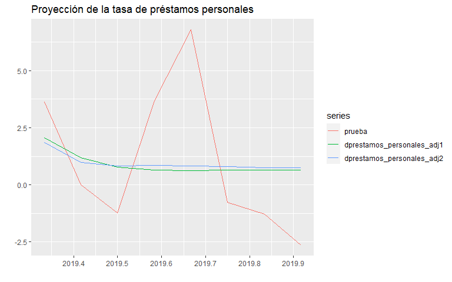

```r
autoplot(cbind(prueba,dprestamos_personales_adj1,dprestamos_personales_adj2))+
  xlab("") + ylab("")+
  ggtitle("Proyección de la tasa de préstamos personales")
```

Como conclusión, el modelo 2 presenta un ajuste levemente mejor, pero la evidencia no es concluyente. Si quisiéramos recuperar el gráfico de las series en niveles tenemos que sumar las diferencias pronosticadas por cada modelo al último período observable e iterar.

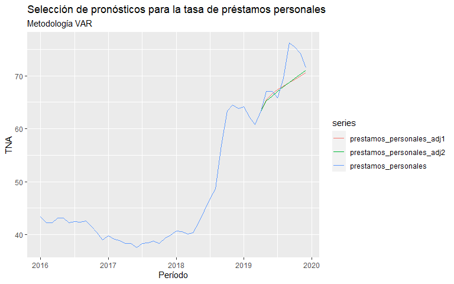

```r
prestamos_personales_adj1 <- prestamos_personales
prestamos_personales_adj2 <- prestamos_personales

for (t in 41:48) {
  prestamos_personales_adj1[t] <- prestamos_personales_adj1[t-1]+dprestamos_personales_adj1[t-40]

  prestamos_personales_adj2[t] <- prestamos_personales_adj2[t-1]+dprestamos_personales_adj2[t-40]
}

#Graficamos
prestamos_personales_adj1 <- ts(prestamos_personales_adj1,
                                 start = c(2016,1), frequency = 12)
prestamos_personales_adj2 <- ts(prestamos_personales_adj2,
                                 start = c(2016,1), frequency = 12)
autoplot(cbind(prestamos_personales_adj1,
               prestamos_personales_adj2,
               prestamos_personales))+
  labs(x="Período", y="TNA",
       title="Selección de pronósticos para la tasa de préstamos personales",
       subtitle = "Metodología VAR")
```

Si eligiéramos el modelo 2, para pronosticar el futuro (más allá de la muestra de prueba) deberíamos reestimar el modelo usando toda la muestra.

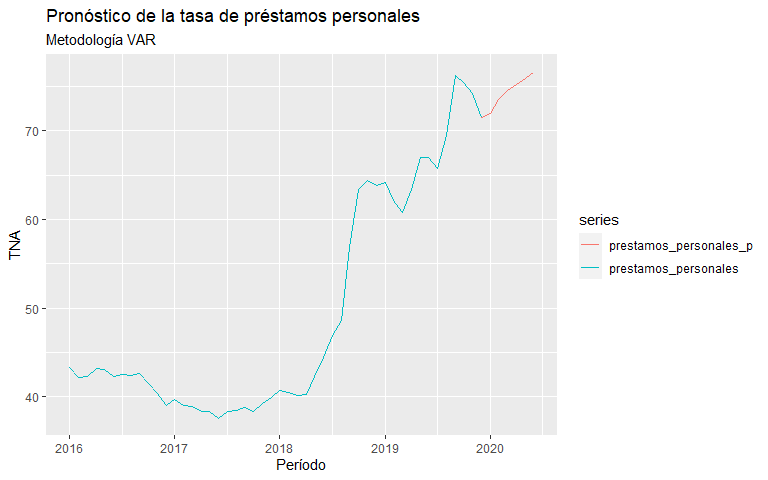

```r
var <- VAR(cbind(dprestamos_personales,dtasa_polmon,dliquidez),
           p=1, type = "const")

pronostico <- forecast(var,h=6)
dprestamos_personales_p <- pronostico$forecast$dprestamos_personales$mean


# En un loop recuperamos la variable en niveles
prestamos_personales_p <- c(prestamos_personales,rep(NA,6))

for (t in 49:54) {
  prestamos_personales_p[t] <- prestamos_personales_p[t-1]+dprestamos_personales_p[t-48]
}


# Graficamos
prestamos_personales_p <- ts(prestamos_personales_p,start = c(2016,1), frequency = 12)
autoplot(cbind(prestamos_personales_p,prestamos_personales))+
  labs(x="Período", y="TNA", title="Pronóstico de la tasa de préstamos personales",
       subtitle="Metodología VAR")
```